# Metformin XR — Bioequivalence Safe Space & VBE Error Rate (PBPK)

Reference formulation: T50 = 3.0 h

Author

Nikita

Published

June 9, 2026

## Background

This report defines the **bioequivalence (BE) safe space** of metformin extended-release (XR) formulations from a validated PK-Sim PBPK model (Open Systems Pharmacology metformin model). Formulation behaviour is varied through the in-vivo dissolution half-time **`T50`**: small `T50` releases fast (higher, earlier C<sub>max</sub>); large `T50` releases slowly.

The **reference formulation is `T50 = 3.0 h`**; every other formulation (`T50` = 1, 2, 3.5, 4, 5, 6, 7 h) is a **test** product assessed against it.

Two analyses are reported:

1. **Point average BE** — the regulatory **CI-based** decision: BE if the **90% CI of the GMR** for both C<sub>max</sub> and AUC lies within **80–125%**.
2. **Virtual BE (VBE)** — resampled `n`-subject crossover trials give the **probability** a real study concludes BE. This curve *is* the safe space; in truly non-equivalent regions its value *is* the **Type I error** (consumer risk).

### Design and settings

- **Paired crossover.** PK-Sim simulates the *same* virtual individuals (IDs 0–23) under every formulation → a fully paired 2×2 crossover (no period/sequence effect); we analyse within-subject log-differences (TOST).
- **VBE:** 500 replicate trials; study sizes **n = 48 and 86 subjects**. *Limitation:* the PBPK population has **24 unique** virtual subjects, so n>24 trials bootstrap with replacement from those 24 physiologies (between-subject diversity is capped at 24).
- **Metric note.** For XR products with heavy AUC extrapolation we lead with **AUC<sub>0-t</sub>**. AUC<sub>∞</sub> is reported but unreliable for slow-release arms (long terminal t½ → large, uncertain extrapolation → wide CIs).
- **Tooling.** Julia + open Pumas-ecosystem packages (DataFrames, CSV, CairoMakie). Licensed Pumas `Bioequivalence`/`NCA` can be swapped in once the env is instantiated with a JuliaHub token; base-R scripts under `programs/R` are an independent cross-check (agree to all digits).

## PK metrics by formulation

Table 1: Geometric-mean PK metrics by formulation (n = 24). The 3.0 h row is the reference. {#tbl-pk}

| T50 (h) | n | GM Cmax (µmol/L) | GM AUC₀-t (µmol·min/L) | GM AUC∞ (µmol·min/L) |
| --- | --- | --- | --- | --- |
| 1.0 | 24 | 29.84 | 16389.0 | 19078.0 |
| 2.0 | 24 | 25.61 | 15613.0 | 19045.0 |
| 3.0 | 24 | 21.97 | 14205.0 | 18885.0 |
| 3.5 | 24 | 20.47 | 13491.0 | 18995.0 |
| 4.0 | 24 | 19.11 | 12806.0 | 19336.0 |
| 5.0 | 24 | 16.8 | 11577.0 | 21138.0 |
| 6.0 | 24 | 15.0 | 10539.0 | 28295.0 |
| 7.0 | 24 | 13.56 | 9671.0 | 34221.0 |

**Inference.** C<sub>max</sub> falls monotonically as release slows (29.8 → 13.6 µmol/L), so it is the BE-determining endpoint. AUC<sub>0-t</sub> falls gently; AUC<sub>∞</sub> is flat then *inflates* for the slow arms (flip-flop kinetics) — a numerical artefact of extrapolation, not extra exposure.

## 1. Point average BE (90% CI decision)

Table 2: Point average-BE vs the 3.0 h reference (paired crossover, n = 24). GMR with 90% CI (%); BE requires the CI ⊂ 80–125%. Overall BE = C<sub>max</sub> and AUC₀-t both Pass. {#tbl-be}

| Test T50 (h) | Cmax GMR | Cmax 90% CI (%) | Cmax | AUC0-t GMR | AUC0-t 90% CI (%) | AUC0-t | AUCinf GMR | AUCinf 90% CI (%) | AUCinf | Overall BE |
| --- | --- | --- | --- | --- | --- | --- | --- | --- | --- | --- |
| 1.0 | 1.358 | 131.86–139.87 | Fail | 1.154 | 112.22–118.63 | Pass | 1.01 | 98.70–103.40 | Pass | Fail |
| 2.0 | 1.166 | 114.79–118.39 | Pass | 1.099 | 108.73–111.12 | Pass | 1.008 | 99.05–102.68 | Pass | Pass |
| 3.5 | 0.932 | 92.70–93.61 | Pass | 0.95 | 94.54–95.41 | Pass | 1.006 | 99.21–101.98 | Pass | Pass |
| 4.0 | 0.87 | 86.30–87.63 | Pass | 0.902 | 89.41–90.90 | Pass | 1.024 | 99.18–105.70 | Pass | Pass |
| 5.0 | 0.765 | 75.74–77.20 | Fail | 0.815 | 80.36–82.66 | Pass | 1.119 | 102.34–122.41 | Pass | Fail |
| 6.0 | 0.682 | 67.48–69.02 | Fail | 0.742 | 72.83–75.59 | Fail | 1.498 | 113.16–198.39 | Fail | Fail |
| 7.0 | 0.617 | 60.95–62.52 | Fail | 0.681 | 66.60–69.61 | Fail | 1.793 | 104.46–307.67 | Fail | Fail |

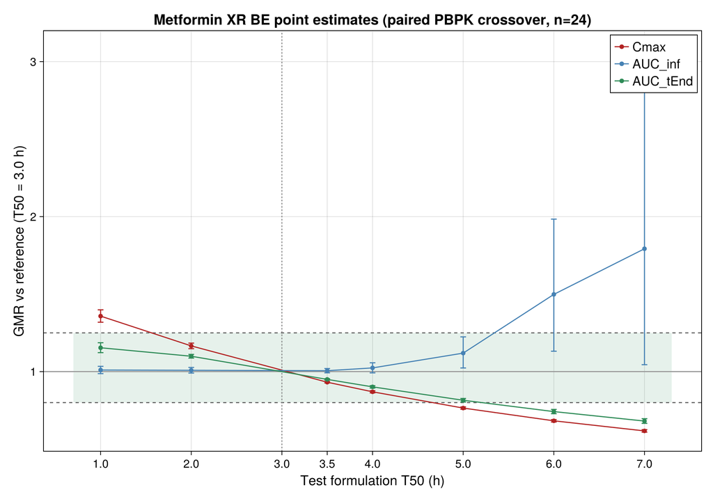

Figure 1: GMR ± 90% CI vs T50. Green band = 80–125% acceptance limits; solid line = unity; dotted line = 3.0 h reference.

**Inference.** The decision is **CI-based, not point-GMR-based**. C<sub>max</sub> drives both edges: fast release (1.0 h) breaches the *upper* limit (GMR 1.36, CI 131.9–139.9%); slow release (≥5.0 h) breaches the *lower* limit. AUC<sub>0-t</sub> fails only at the slow extreme; AUC<sub>∞</sub> shows spuriously wide CIs at 6–7 h from extrapolation. Formulations passing **both** C<sub>max</sub> and AUC<sub>0-t</sub>: **T50 = 2.0, 3.0 (ref), 3.5, 4.0 h**.

## 2. Within-subject variability (sourced)

Metformin is a **low-variability** drug. Intra-subject CVs adopted for the VBE simulation (extended-release):

Table 3: Sourced metformin within-subject (intra-subject) CV. The VBE uses the FDA ER values (C<sub>max</sub> 12.2%, AUC₀-t 11.2%, AUC∞ 11.4%). Inter-subject CV for contrast: 18.4% / 20.6%. {#tbl-cv}

| Source | Cmax intra-CV | AUC intra-CV |
| --- | --- | --- |
| FDA NDA 212595 ClinPharm review (ER) — primary | 12.2% | 11.2% (AUC₀-t), 11.4% (AUC∞) |
| Chung et al. 2018, Transl Clin Pharmacol 26(1):6–9 (ER) | 14.3% | 10.3% |
| Metformin IR tablets (literature) — high-variability bound | ≈23.7% | — |

**Inference.** Because intra-subject CV is low (~11–12%), a modest study (n = 24–48) already has high power to *detect* equivalence near the reference — the safe-space edges are therefore set by the *true* formulation difference (C<sub>max</sub> vs T50), not by trial noise.

## 3. VBE safe space by endpoint (500 trials; n = 48 and 86)

The safe space is the `T50` band where a trial reliably (power ≥ 80%) concludes BE. Green = safe, red = fail; open circles are the 8 simulated formulations; the curve interpolates each subject’s response between them.

### C<sub>max</sub> (BE-determining endpoint)

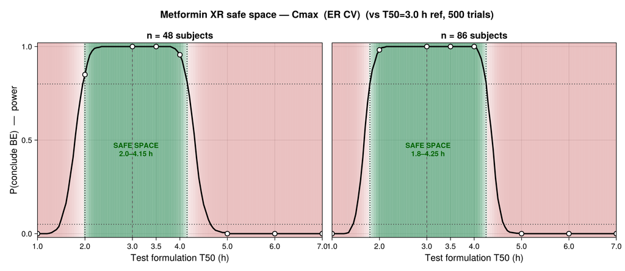

Figure 2: Safe space for C<sub>max</sub>, n = 48 (left) and n = 86 (right).

**Inference.** C<sub>max</sub> gives the **narrowest** safe space (n=48: **2.00–4.15 h**; n=86: **1.80–4.25 h**), so it governs the overall decision. Increasing n from 48→86 widens the band only slightly (≈0.3 h) — consistent with low intra-subject CV: power near the edges is already high, and the edges are driven by the true GMR crossing 80/125%, which more subjects cannot move.

### AUC<sub>0-t</sub>

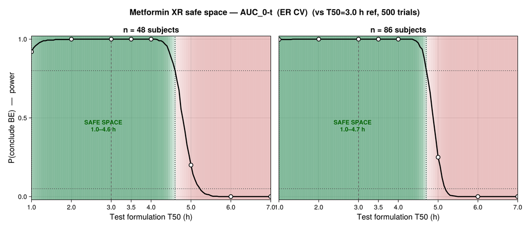

Figure 3: Safe space for AUC₀-t, n = 48 (left) and n = 86 (right).

**Inference.** AUC<sub>0-t</sub> is more permissive (≈**1.0–4.6/4.7 h**): exposure changes less than peak with release rate, so only the slow extreme fails. It never limits the joint decision on the fast side.

### AUC<sub>∞</sub>

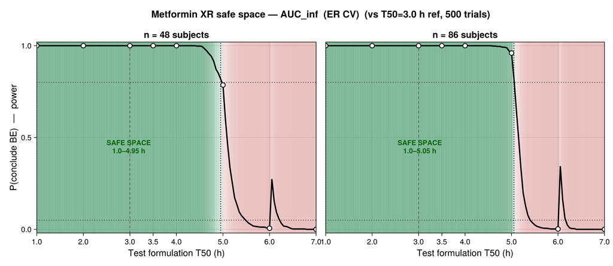

Figure 4: Safe space for AUC∞, n = 48 (left) and n = 86 (right).

**Inference.** AUC<sub>∞</sub> appears widest (≈**1.0–5.0 h**) but this is **not reliable**: for slow arms the long terminal t½ forces heavy, uncertain extrapolation (and dropped subjects at 7 h), inflating the GMR and CI. AUC<sub>∞</sub> should not drive the XR safe space — use AUC<sub>0-t</sub>.

### Joint decision (C<sub>max</sub> & AUC<sub>0-t</sub>)

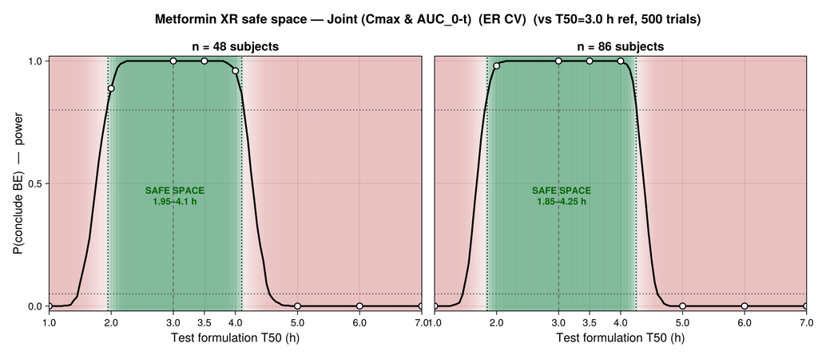

Figure 5: Safe space for the joint BE decision (a trial passes only if both C<sub>max</sub> and AUC₀-t pass).

**Inference.** The regulatory safe space is the joint pass region, which equals the C<sub>max</sub> band (C<sub>max</sub> is limiting): **n=48 ≈ 1.95–4.10 h, n=86 ≈ 1.85–4.25 h** around the 3.0 h reference.

### Safe-space boundaries and VBE pass-rates

Table 4: Safe-space T50 range (power ≥ 80%) by endpoint and study size. {#tbl-bounds}

| Endpoint | n = 48 | n = 86 |
| --- | --- | --- |
| Cmax | 2.00–4.15 h | 1.80–4.25 h |
| AUC_inf | 1.00–4.95 h | 1.00–5.05 h |
| AUC_0-t | 1.00–4.60 h | 1.00–4.70 h |
| Joint (Cmax & AUC_0-t) | 1.95–4.10 h | 1.85–4.25 h |

Table 5: VBE pass-rate = P(conclude BE), 500 trials. Inside the safe space this is POWER; where the true GMR is outside 80–125% it is the TYPE I error (target ≤ 5%). {#tbl-power}

| Test T50 (h) | Cmax n48 | Cmax n86 | AUC_tEnd n48 | AUC_tEnd n86 | AUC_inf n48 | AUC_inf n86 |
| --- | --- | --- | --- | --- | --- | --- |
| 1.0 | 0.0% | 0.0% | 92.0% | 99.8% | 100.0% | 100.0% |
| 2.0 | 85.0% | 98.2% | 100.0% | 100.0% | 100.0% | 100.0% |
| 3.5 | 100.0% | 100.0% | 100.0% | 100.0% | 100.0% | 100.0% |
| 4.0 | 95.6% | 100.0% | 100.0% | 100.0% | 100.0% | 100.0% |
| 5.0 | 0.0% | 0.0% | 20.0% | 25.0% | 78.6% | 96.0% |
| 6.0 | 0.0% | 0.0% | 0.0% | 0.0% | 0.6% | 0.2% |
| 7.0 | 0.0% | 0.0% | 0.0% | 0.0% | 0.0% | 0.0% |

**Inference.** Pass-rates are ~100% inside the safe space and collapse to **0–0.6%** at the truly non-equivalent slow arms (6–7 h) — Type I error is **well controlled** (≤ 5%). The borderline arms (5 h AUC) show the expected power gain with n (e.g. AUC<sub>∞</sub> 78.6% → 96.0%).

## Conclusions

- **Reference:** T50 = 3.0 h.
- **Point-BE safe set (simulated formulations):** T50 = 2.0, 3.0, 3.5, 4.0 h (C<sub>max</sub> & AUC₀-t, 90% CI ⊂ 80–125%).
- **Continuous VBE safe space (joint, power ≥ 80%):** ≈ 1.9–4.1 h (n = 48), 1.85–4.25 h (n = 86).
- **C<sub>max</sub> is the BE-determining endpoint**; AUC<sub>0-t</sub> and (artefactually) AUC<sub>∞</sub> are more permissive.
- Larger study size (48 → 86) widens the safe space only marginally — a signature of metformin’s **low intra-subject variability**; the edges are set by the true formulation effect, not trial noise.
- **Type I error is controlled** (≤ 5%) at truly non-equivalent formulations.

### Next steps (per MAP)

- Fit the **PopPK** model to a sparsely-sampled, residual-error version of these PBPK profiles, repeat this VBE workflow, and overlay the PBPK vs PopPK safe-space curves (decision equivalence).
- Add the IR high-variability (≈23.7%) scenario to bracket the safe space under higher CV.